# Vores tilmeldinger

Christian Knudsen

2026-10-31

Vi har lidt udfordringer. Der er huller i dataindsamlingen. Eksempelvis har vi en venteliste på et kursus som vi ikke har tilmeldingsdata til….

Det kan jeg ikke løse i koden.

Der er også lidt andre sjuskefejl, hvor samme kursus optræder med mere end en tilmeldingsliste. Det *kan* jeg løse i koden. Og tager den nyeste af dem.

## Teknik

Vi gemmer regelmæssigt tilmeldingerne til vores kurser. Tag et kig på repoet til denne side (github.com/kubdatalab/tal-og-data), og studer filen “read_kursus_tilmeldinger.R” hvis du er nysgerring på oprensningen af data. Hiver du selv repoet ned, skal du være opmærksom på, at alle filerne skal hentes ned, og gemmes i mappen /data-raw/kursus_tilmeldinger

Den er ikke automatisk med, da .gitignore sikrer at den ikke kommer med op på github.

Den behandling fører til tre csv-filer:

- presenter.csv med et id på kurset, og et undervisernavn. Det er nemlig en en til mange forbindelse.
- metadata.csv der også har et id på kurset - og dertil diverse oplysninger om navn, R/python kategori, tid, sted og dato.
- tilmeldinger.csv der har de egentlige tilmeldingsdata. Herunder et pid der er en hashet udgave af emailadressen på tilmeldingen - det gør det tilnærmelsesvist muligt at identificere gengangere. Og en sex-kolonne, der på en skala fra 0 til 1 angiver hvor sandsynlig det er at deltagere er en mand - baseret på data for hyppigheden af mænd/kvinder med et givet fornavn (fra 2021, så…)

## Cave

Hvis du føler trang til at sammenligne med de tal der trækkes gennem API’en og er publiceret på https://kubdatalab.github.io/tal-og-data/tallene.html så husk at det er løbende tale inklusive ventelister, studerende der har tilmeldt sig men melder fra igen osv. Så de er altså ikke direkte sammenlignelige. For ikke at tale om at 2024 tallene ikke er for hele året.

Perioden der her undersøges: 2024-05-27 19:27:00 til 2025-04-30 14:38:00

### registration type

```r
tilmeldinger %>%
  count(registration_type)
```

```
## # A tibble: 2 × 2
##   registration_type     n
##   <chr>             <int>
## 1 In-Person          1206
## 2 Online              115
```

## Antal tilmeldinger:

```r
tilmeldinger %>%
  group_by(year) %>%
  summarise(antal = n())
```

```
## # A tibble: 2 × 2
##    year antal
##   <dbl> <int>
## 1  2024   668
## 2  2025   653
```

## Kønsfordeling

```r
tilmeldinger %>%
  group_by(sex) %>%
  summarise(antal = n())
```

```
## # A tibble: 3 × 2
##   sex   antal
##   <chr> <int>
## 1 f       711
## 2 m       304
## 3 <NA>    306
```

#### fakulteter

```r
tilmeldinger %>%
  group_by(faculty) %>%
  summarise(antal = n())
```

```
## # A tibble: 10 × 2
##    faculty                                       antal
##    <chr>                                         <int>
##  1 -                                                 5
##  2 Faculty of Health and Medical Sciences (UCPH)   173
##  3 Faculty of Humanities (UCPH)                    231
##  4 Faculty of Law (UCPH)                             9
##  5 Faculty of Science (UCPH)                       329
##  6 Faculty of Social Sciences (UCPH)               282
##  7 Faculty of Theology (UCPH)                        9
##  8 Not related to any university                     4
##  9 Other university than UCPH                       22
## 10 <NA>                                            257
```

#### uddannelser

```r
tilmeldinger %>%
  mutate(udd = tolower(udd)) %>%
  count(udd)
```

```
## # A tibble: 268 × 2
##    udd                            n
##    <chr>                      <int>
##  1 -                              5
##  2 4cities urban studies          1
##  3 advanced migration studies    14
##  4 african studies                3
##  5 agriculture                    5
##  6 agriculture economics          1
##  7 agriculture-plant science      1
##  8 agronomy                       1
##  9 analytical chemistry           1
## 10 animal science                 7
## # ℹ 258 more rows
```

Held og lykke med at finde hoved og hale i det…

#### Hvornår kommer tilmeldingerne?

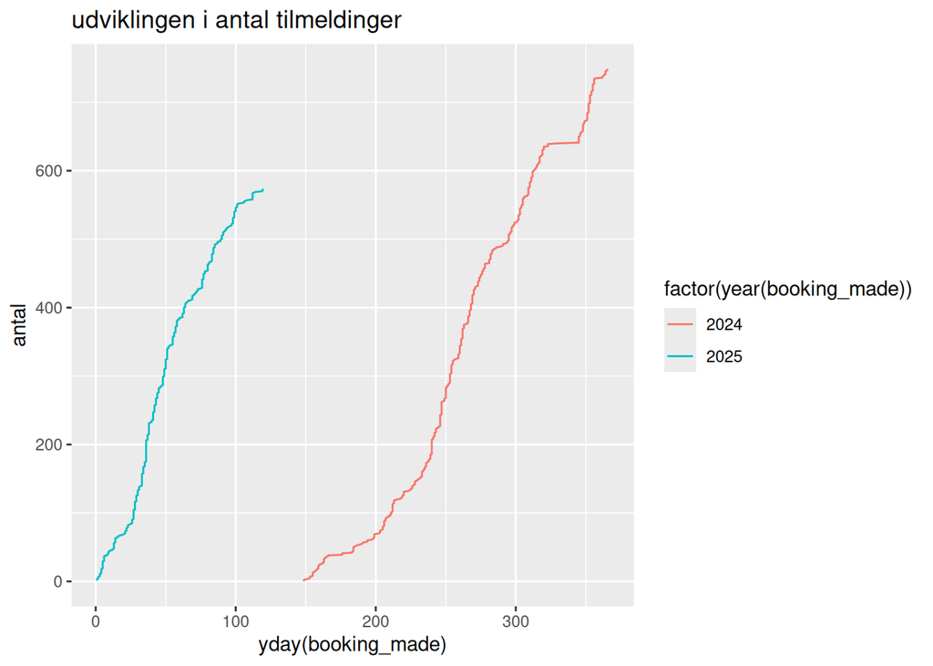

```r
tilmeldinger %>%
  select(booking_made) %>%
  arrange(booking_made) %>%
  group_by(year(booking_made)) %>%
  mutate(antal = row_number()) %>%
  ggplot(aes(x=yday(booking_made),y = antal, color = factor(year(booking_made)))) +
  geom_line() +
  ggtitle("udviklingen i antal tilmeldinger")
```

#### Online eller fysiske kurser:

```r
tilmeldinger %>% count(registration_type)
```

```
## # A tibble: 2 × 2
##   registration_type     n
##   <chr>             <int>
## 1 In-Person          1206
## 2 Online              115
```

### Hvilke fakulteter?

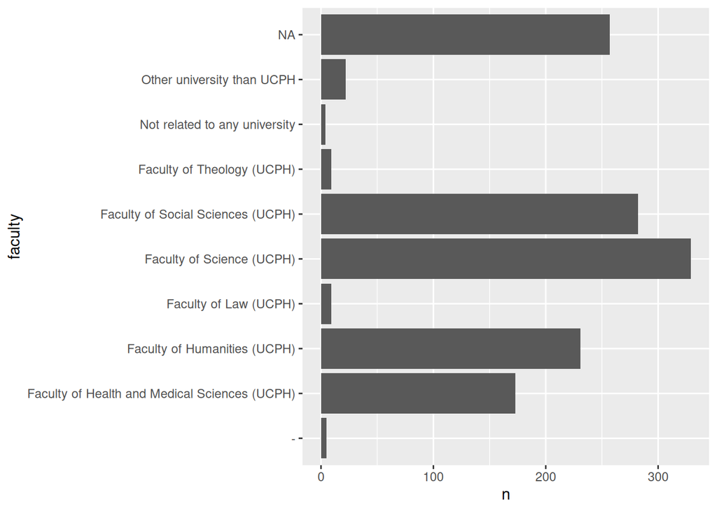

```r
tilmeldinger %>% count(faculty) %>%
  ggplot(aes(faculty, n)) +
  geom_col() +
  coord_flip()
```

#### udd. niveua

```r
tilmeldinger %>% count(niveau)
```

```
## # A tibble: 6 × 2
##   niveau       n
##   <chr>    <int>
## 1 -            5
## 2 Bachelor   299
## 3 Master     667
## 4 Other       36
## 5 PhD         57
## 6 <NA>       257
```

### erfaring med emnet:

```r
tilmeldinger %>% count(erfaring)
```

```
## # A tibble: 5 × 2
##   erfaring         n
##   <chr>        <int>
## 1 -                5
## 2 Advanced         1
## 3 Intermediate    82
## 4 Novice         976
## 5 <NA>           257
```

#### os

```r
tilmeldinger %>%
  count(os)
```

```
## # A tibble: 5 × 2
##   os                 n
##   <chr>          <int>
## 1 -                  5
## 2 Linux or other     3
## 3 Windows          563
## 4 macOS            493
## 5 <NA>             257
```

#### kilde

```r
tilmeldinger %>%
  count(kilde)
```

```
## # A tibble: 8 × 2
##   kilde                           n
##   <chr>                       <int>
## 1 -                               5
## 2 KUnet                         610
## 3 Other                          61
## 4 Poster or flyer                16
## 5 The library's Facebook page     1
## 6 The library's web page        233
## 7 Word of mouth                 138
## 8 <NA>                          257
```

#### kontakttilladelse

```r
tilmeldinger %>%
  count(kontakt_tilladelse)
```

```
## # A tibble: 4 × 2
##   kontakt_tilladelse     n
##   <chr>              <int>
## 1 -                      5
## 2 No                   274
## 3 Yes                  785
## 4 <NA>                 257
```

#### køn

```r
tilmeldinger %>%
  count(sex)
```

```
## # A tibble: 3 × 2
##   sex       n
##   <chr> <int>
## 1 f       711
## 2 m       304
## 3 <NA>    306
```

## Nå. Vi må hellere gå lidt systematisk til værks.

### Styresystem

#### Styresystem:

```r
tilmeldinger %>% count(os)
```

```
## # A tibble: 5 × 2
##   os                 n
##   <chr>          <int>
## 1 -                  5
## 2 Linux or other     3
## 3 Windows          563
## 4 macOS            493
## 5 <NA>             257
```

#### Er der forskel på fakulteterne?

den skal være procentuel

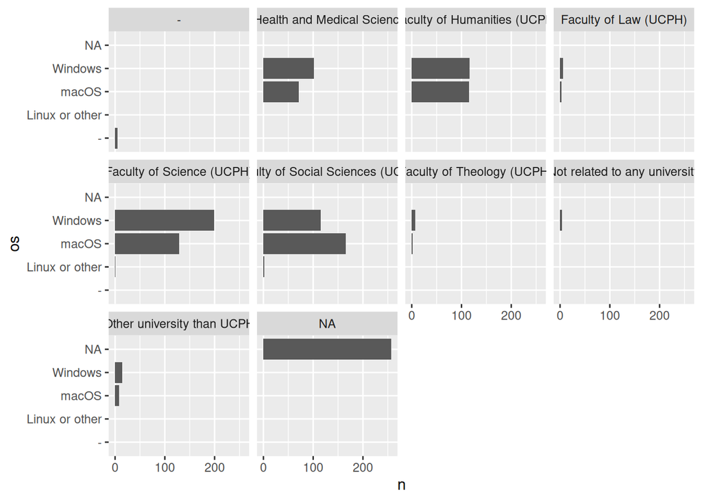

```r
tilmeldinger %>% group_by(faculty) %>%
  count(os) %>%
  ggplot(aes(os, n)) +
  geom_col() +
  facet_wrap(~faculty) +
  coord_flip()
```

#### er der forskel på kønnene?

```r
tilmeldinger %>%
  group_by(sex) %>%
  count(os) %>%
  pivot_wider(names_from = sex, values_from = n)
```

```
## # A tibble: 5 × 4
##   os                 f     m  `NA`
##   <chr>          <int> <int> <int>
## 1 -                  3     2    NA
## 2 Linux or other     2     1    NA
## 3 Windows          339   189    35
## 4 macOS            367   112    14
## 5 <NA>              NA    NA   257
```

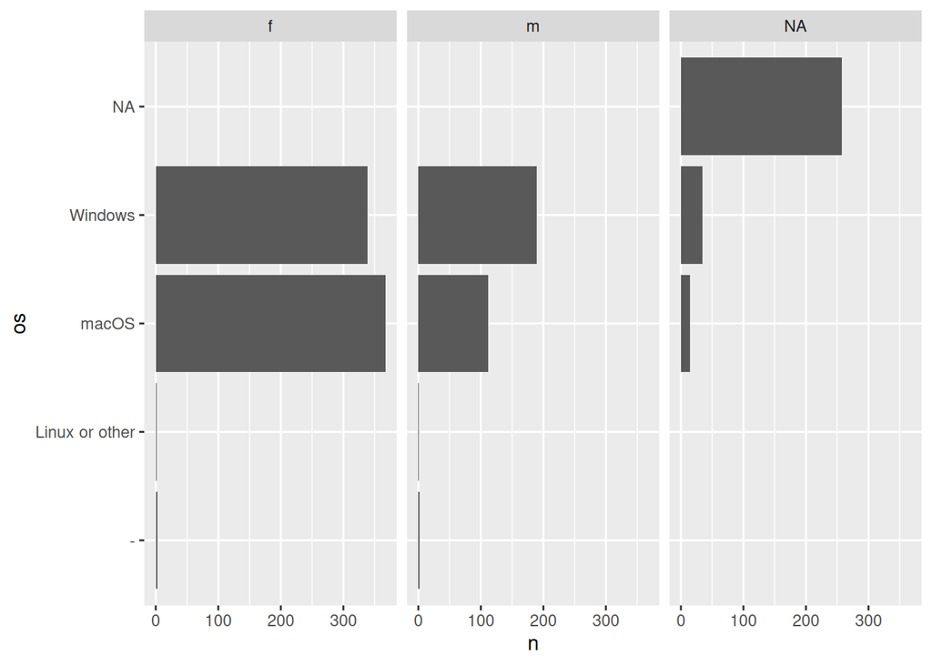

```r
tilmeldinger %>%
  group_by(sex) %>%
  count(os) %>%
  ggplot(aes(os, n)) +
  geom_col() +
  facet_wrap(~sex) +
  coord_flip()
```

#### Styresystem vs. niveau

```r
tilmeldinger %>%
  group_by(niveau) %>%
  count(os) %>%
  pivot_wider(names_from = os, values_from= n)
```

```
## # A tibble: 6 × 6
## # Groups:   niveau [6]
##   niveau     `-` Windows macOS `Linux or other`  `NA`
##   <chr>    <int>   <int> <int>            <int> <int>
## 1 -            5      NA    NA               NA    NA
## 2 Bachelor    NA     130   169               NA    NA
## 3 Master      NA     355   310                2    NA
## 4 Other       NA      29     6                1    NA
## 5 PhD         NA      49     8               NA    NA
## 6 <NA>        NA      NA    NA               NA   257
```

#### Styresystem vs. erfaring

```r
tilmeldinger %>%
    group_by(erfaring) %>%
  count(os) %>%
  pivot_wider(names_from=os, values_from = n)
```

```
## # A tibble: 5 × 6
## # Groups:   erfaring [5]
##   erfaring       `-` Windows `Linux or other` macOS  `NA`
##   <chr>        <int>   <int>            <int> <int> <int>
## 1 -                5      NA               NA    NA    NA
## 2 Advanced        NA       1               NA    NA    NA
## 3 Intermediate    NA      39                1    42    NA
## 4 Novice          NA     523                2   451    NA
## 5 <NA>            NA      NA               NA    NA   257
```

# den procentuelle kønsfordeling fordelt på hvilke fakulteter de kommer fra.

Husk at sammenligne med kønsfordelingen på fakulteterne.

```r
tilmeldinger %>%
  group_by(faculty, sex) %>%
  summarise(antal = n()) %>%
  ungroup() %>%
  filter(!is.na(sex)) %>%
  group_by(faculty) %>%
  mutate(andel = antal/sum(antal)*100) %>%
  select(-antal) %>%
  pivot_wider(names_from = sex, values_from = andel)
```

[output not shown]

```
## # A tibble: 9 × 3
## # Groups:   faculty [9]
##   faculty                                           f     m
##   <chr>                                         <dbl> <dbl>
## 1 -                                              60    40
## 2 Faculty of Health and Medical Sciences (UCPH)  76.9  23.1
## 3 Faculty of Humanities (UCPH)                   77.1  22.9
## 4 Faculty of Law (UCPH)                          55.6  44.4
## 5 Faculty of Science (UCPH)                      69.0  31.0
## 6 Faculty of Social Sciences (UCPH)              61.3  38.7
## 7 Faculty of Theology (UCPH)                     66.7  33.3
## 8 Not related to any university                 100    NA
## 9 Other university than UCPH                     72.2  27.8
```

Det er så kun et estimat baseret på fornavne. Hvis ikke DS har tal på kønsfordelingen for et givet fornavn, optræder man som NA. Der skal selvfølgelig her sammenlignes med kønsfordelingen på de enkelte fakulteter.

#### Hvad er det foretrukne overordnede emne fordelt på fakulteterne?

```r
tilmeldinger %>%
  left_join(metadata) %>%
  select(faculty,gruppe) %>%
  group_by(faculty, gruppe) %>%
  summarise(antal = n()) %>%
  pivot_wider(names_from = gruppe, values_from = antal)
```

```
## `summarise()` has regrouped the output.
```

```
## # A tibble: 10 × 6
## # Groups:   faculty [10]
##    faculty                                       nvivo     r  `NA` python orange
##    <chr>                                         <int> <int> <int>  <int>  <int>
##  1 -                                                 1     1     3     NA     NA
##  2 Faculty of Health and Medical Sciences (UCPH)    25    94    27     27     NA
##  3 Faculty of Humanities (UCPH)                     45    27    54     99      6
##  4 Faculty of Law (UCPH)                             1     1     2      5     NA
##  5 Faculty of Science (UCPH)                        20   125    55    127      2
##  6 Faculty of Social Sciences (UCPH)                57    71    41    107      6
##  7 Faculty of Theology (UCPH)                        1     2     3      2      1
##  8 Not related to any university                     1     1     1      1     NA
##  9 Other university than UCPH                        5     5     1     11     NA
## 10 <NA>                                             32   107    26     88      4
```

det er antal - så hvis man vil have procenter skal man tage stilling til hvilken margen man vil summere på.

Vi skal have summen med også

# hvilke dage?

```r
tilmeldinger %>% left_join(metadata) %>%
  mutate(uge_dag = lubridate::wday(dato, label = TRUE)) %>%
  group_by(uge_dag, filename) %>%
  summarise(antal_tilmeldinger = n()) %>%
  summarise(antal_tilmeldinger = sum(antal_tilmeldinger),
            antal_kurser = n(),
            middel_tilmeldinger = antal_tilmeldinger/antal_kurser)
```

```
## `summarise()` has regrouped the output.
```

```
## # A tibble: 6 × 4
##   uge_dag antal_tilmeldinger antal_kurser middel_tilmeldinger
##   <ord>                <int>        <int>               <dbl>
## 1 Mon                    162           12                13.5
## 2 Tue                    450           24                18.8
## 3 Wed                    234           15                15.6
## 4 Thu                    130            8                16.2
## 5 Fri                    193           16                12.1
## 6 <NA>                   152            8                19
```

Som det ser ud i skrivende stund, er mandage og fredage dårlige tidspunkter mhp tilmeldinger.

# hvilke tidspunkter?

```r
tilmeldinger %>%
  left_join(metadata) %>%
  group_by(from, filename) %>%
  summarise(antal_tilmeldinger = n()) %>%
  summarise(antal_tilmeldinger = sum(antal_tilmeldinger),
            antal_kurser = n(),
            middel_tilmeldinger = antal_tilmeldinger/antal_kurser)
```

```
## `summarise()` has regrouped the output.
```

```
## # A tibble: 9 × 4
##   from   antal_tilmeldinger antal_kurser middel_tilmeldinger
##   <time>              <int>        <int>               <dbl>
## 1 09:00                 339           15                22.6
## 2 09:30                 154           13                11.8
## 3 10:00                 325           24                13.5
## 4 11:00                   9            1                 9
## 5 12:00                 114            6                19
## 6 12:30                  80            6                13.3
## 7 13:00                 131            9                14.6
## 8 13:30                  17            1                17
## 9    NA                 152            8                19
```

## fordeling af tilmeldinger på type af kurser

```r
tilmeldinger %>%
  left_join(metadata) %>%
  group_by(year, gruppe, kursus_id) %>%
  mutate(antal = n()) %>%
  ungroup() %>%
  select(gruppe, antal, year, kursus_id) %>%
  distinct() %>%
  group_by(year, gruppe)  %>%
  summarise(tilmeldinger = sum(antal),
            antal_kurser = n()) %>%
  ungroup() %>%
  group_by(year,gruppe) %>%
  summarise(gennemsnit = tilmeldinger/antal_kurser) %>%
  pivot_wider(names_from = year, values_from = gennemsnit)
```

```
## `summarise()` has regrouped the output.
## `summarise()` has regrouped the output.
```

```
## # A tibble: 5 × 3
##   gruppe `2024` `2025`
##   <chr>   <dbl>  <dbl>
## 1 nvivo    16     15.4
## 2 orange    4      5.5
## 3 python   17.6   14
## 4 r        21.9   17.9
## 5 <NA>     16.5   11.6
```

## Fordeling af fag på R-kurserne.

```r
tilmeldinger %>%
  left_join(metadata, by = join_by(kursus_id)) %>%
  filter(gruppe == "r") %>%
  select(Event, faculty, udd) %>%
  group_by(Event) %>%
  count(faculty) %>%
  pivot_wider(names_from = faculty, values_from = n, values_fill = 0) %>%
  mutate(total = sum(c_across(where(is.integer))),
         across(where(is.integer), ~.x/total)
         ) %>%
  mutate(across(where(is.numeric), scales::percent)) %>%
  select(-total) %>%
  ungroup() %>%
  kable()
```

| Event | Faculty of Health and Medical Sciences (UCPH) | Faculty of Humanities (UCPH) | Faculty of Science (UCPH) | Faculty of Social Sciences (UCPH) | NA | Faculty of Theology (UCPH) | Not related to any university | Other university than UCPH | - | Faculty of Law (UCPH) |
| --- | --- | --- | --- | --- | --- | --- | --- | --- | --- | --- |
| Explorative data analysis with R | 14% | 9% | 31% | 11% | 34% | 0% | 0% | 0% | 0% | 0% |
| Introduction to visualizing with ggplot2 in R | 0% | 0% | 0% | 0% | 100% | 0% | 0% | 0% | 0% | 0% |
| R and APIs - Statistics Denmark | 4% | 4% | 17% | 8% | 67% | 0% | 0% | 0% | 0% | 0% |
| R for Absolute Beginners | 20% | 5% | 28% | 25% | 18% | 1% | 1% | 1% | 0% | 0% |
| R for Absolute Beginners - ONLINE | 21% | 11% | 50% | 16% | 0% | 0% | 0% | 2% | 1% | 0% |
| R for absolutte nybegyndere | 35% | 4% | 22% | 18% | 19% | 1% | 0% | 1% | 0% | 1% |
| Text mining and text analysis with R | 33% | 0% | 33% | 33% | 0% | 0% | 0% | 0% | 0% | 0% |
| Text mining with R | 0% | 17% | 67% | 17% | 0% | 0% | 0% | 0% | 0% | 0% |

Hvor lang tid i forvejen tilmelder de sig kurserne?

Gennemsnit for alle kurser:

```r
tilmeldinger %>%
  left_join(metadata) %>%
  mutate(kursus_tid = as.POSIXct(paste(dato, from), optional = TRUE)) %>%
  mutate(tid_before= as.numeric(kursus_tid - booking_made, units = "days")) %>%
  summarise(gennemsnit = mean(tid_before))
```

```
## # A tibble: 1 × 1
##   gennemsnit
##        <dbl>
## 1         NA
```

Og det var i dage.

[figure not shown]

```r
tilmeldinger %>%
  left_join(metadata) %>%
  mutate(kursus_tid = as.POSIXct(paste(dato, from), optional = TRUE)) %>%
  mutate(tid_before= as.numeric(kursus_tid - booking_made, units = "days")) %>%
  ggplot(aes(tid_before)) +
  geom_density() +
  ggtitle("sandsynlighedsfordelingen for hvor lang tid i forvejen tilmeldingerne falder")
```

Nu kunne det jo være interessant at se om det er dem der tilmeldte sig i meget god tid der falder fra.